```python
import numpy as np
import pandas as pd
import matplotlib.pyplot as plt
from PIL import  Image
%matplotlib inline
import seaborn as sns
from sklearn.preprocessing import StandardScaler
```

```python
data = pd.read_csv(r"D:/Development/TechMahindra/WA_Fn-UseC_-Telco-Customer-Churn.csv")
```

# Data Insights

In the data provided, Churn(Yes/No) is visualised against all other features of the data to decide on the features to be used for the Classification Model.

```python
data.info()
```

```
<class 'pandas.core.frame.DataFrame'>
RangeIndex: 7043 entries, 0 to 7042
Data columns (total 21 columns):
customerID          7043 non-null object
gender              7043 non-null object
SeniorCitizen       7043 non-null int64
Partner             7043 non-null object
Dependents          7043 non-null object
tenure              7043 non-null int64
PhoneService        7043 non-null object
MultipleLines       7043 non-null object
InternetService     7043 non-null object
OnlineSecurity      7043 non-null object
OnlineBackup        7043 non-null object
DeviceProtection    7043 non-null object
TechSupport         7043 non-null object
StreamingTV         7043 non-null object
StreamingMovies     7043 non-null object
Contract            7043 non-null object
PaperlessBilling    7043 non-null object
PaymentMethod       7043 non-null object
MonthlyCharges      7043 non-null float64
TotalCharges        7043 non-null object
Churn               7043 non-null object
dtypes: float64(1), int64(2), object(18)
memory usage: 1.1+ MB
```

#Data PreProcessing : For the data to be compatible with Machine Learning algorithm, Preprocessing is performed. 1. In the 'SeniorCitizen' column 1 or 0 is replaced for Yes or No 2. 'No Internet Service' is replaced with No in few columns as both No and 'No internet service' mean the same 3. TotalCharges column had few blanks, which are being replaced with 'nan' 4. Tenure is divided into categories and the values are updated in the dataframe

```python
data["SeniorCitizen"] = data["SeniorCitizen"].replace({1:"Yes",0:"No"})
```

```python
columns_to_replace = [ 'OnlineSecurity', 'OnlineBackup', 'DeviceProtection','TechSupport','StreamingTV', 'StreamingMovies']
for i in columns_to_replace :
    data[i]  = data[i].replace({'No internet service' : 'No'})
```

```python
data['TotalCharges'] = data["TotalCharges"].replace(" ",np.nan)
```

```python
def tenure_category(data) :

    if data["tenure"] <= 12 :
        return "Tenure_0-12"
    elif (data["tenure"] > 12) & (data["tenure"] <= 24 ):
        return "Tenure_12-24"
    elif (data["tenure"] > 24) & (data["tenure"] <= 48) :
        return "Tenure_24-48"
    elif (data["tenure"] > 48) & (data["tenure"] <= 60) :
        return "Tenure_48-60"
    elif data["tenure"] > 60 :
        return "Tenure_gt_60"
data["tenure_category"] = data.apply(lambda data:tenure_category(data),axis = 1)
```

#Average TotalCharge is found for each tenure Category and the blanks in TotalCharge are replaced with average TotalCharge for the respective tenure category

```python
data_copy = data.copy()
```

```python
data.groupby(['tenure_category']).mean()
```

| tenure_category | tenure | MonthlyCharges |
| --- | --- | --- |
| Tenure_0-12 | 4.731473 | 56.097781 |
| Tenure_12-24 | 18.351562 | 61.357275 |
| Tenure_24-48 | 36.191343 | 65.930552 |
| Tenure_48-60 | 54.489183 | 70.550781 |
| Tenure_gt_60 | 68.110163 | 75.952701 |

```python
data_copy = data_copy[data_copy["TotalCharges"].notnull()]
data_copy = data_copy.reset_index()[data_copy.columns]
```

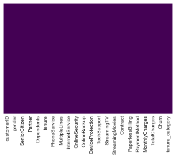

```python
sns.heatmap(data_copy.isnull(),yticklabels=False,cbar=False,cmap='viridis')
```

```python
data_copy["TotalCharges"] = data_copy["TotalCharges"].astype(float)
Avg_totalcharge = data_copy.groupby(['tenure_category']).mean()
Avg_totalcharge.loc['Tenure_0-12']['TotalCharges']
```

```
276.6215632183913
```

```python
def impute_TotalCharges(cols):
    TotalCharges = cols[0]
    tenure_category = cols[1]
    if pd.isnull(TotalCharges):
        return Avg_totalcharge.loc[tenure_category]['TotalCharges']
    else:
        return TotalCharges
```

```python
data['TotalCharges']=data[['TotalCharges','tenure_category']].apply(impute_TotalCharges,axis=1)
```

#Data is checked for Null values

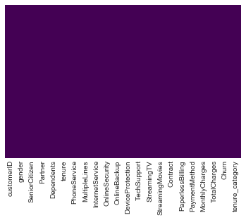

```python
sns.heatmap(data.isnull(),yticklabels=False,cbar=False,cmap='viridis')
```

```python
#Cross-validation of TotalCharge update
data[(data.customerID == '4075-WKNIU')]
```

|  | customerID | gender | SeniorCitizen | Partner | Dependents | tenure | PhoneService | MultipleLines | InternetService | OnlineSecurity | ... | TechSupport | StreamingTV | StreamingMovies | Contract | PaperlessBilling | PaymentMethod | MonthlyCharges | TotalCharges | Churn | tenure_category |
| --- | --- | --- | --- | --- | --- | --- | --- | --- | --- | --- | --- | --- | --- | --- | --- | --- | --- | --- | --- | --- | --- |
| 6670 | 4075-WKNIU | Female | No | Yes | Yes | 0 | Yes | Yes | DSL | No | ... | Yes | Yes | No | Two year | No | Mailed check | 73.35 | 276.622 | No | Tenure_0-12 |

1 rows × 22 columns

```python
data["TotalCharges"] = data["TotalCharges"].astype(float)
```

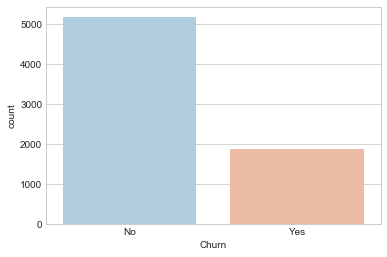

```python
sns.set_style('whitegrid')
sns.countplot(x='Churn',data=data,palette='RdBu_r')
```

```python
import cufflinks as cf
cf.go_offline()
data['Churn'].iplot(kind='hist',title="Churn count")
```

[interactive chart not shown]

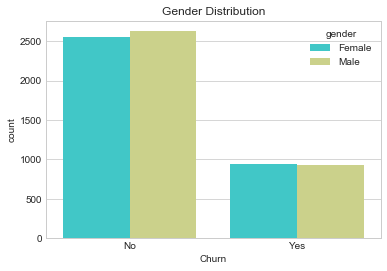

```python
sns.set_style('whitegrid')
sns.countplot(x='Churn',hue='gender',data=data,palette='rainbow').set_title("Gender Distribution")
```

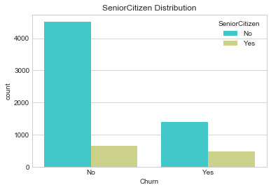

```python
sns.countplot(x='Churn',hue='SeniorCitizen',data=data,palette='rainbow').set_title("SeniorCitizen Distribution")
```

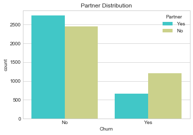

```python
sns.countplot(x='Churn',hue='Partner',data=data,palette='rainbow').set_title("Partner Distribution")
```

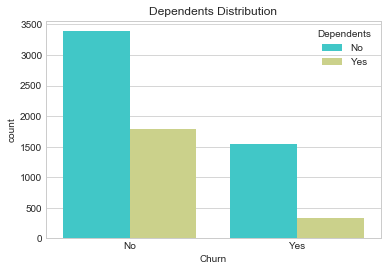

```python
sns.countplot(x='Churn',hue='Dependents',data=data,palette='rainbow').set_title("Dependents Distribution")
```

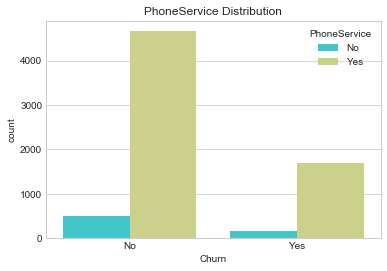

```python
sns.countplot(x='Churn',hue='PhoneService',data=data,palette='rainbow').set_title("PhoneService Distribution")
```

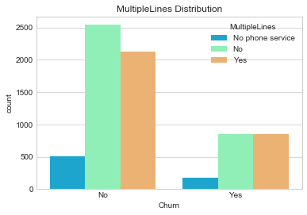

```python
sns.countplot(x='Churn',hue='MultipleLines',data=data,palette='rainbow').set_title("MultipleLines Distribution")
```

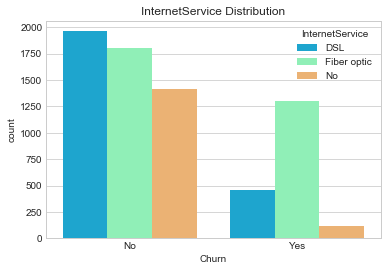

```python
sns.countplot(x='Churn',hue='InternetService',data=data,palette='rainbow').set_title("InternetService Distribution")
```

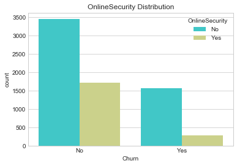

```python
sns.countplot(x='Churn',hue='OnlineSecurity',data=data,palette='rainbow').set_title("OnlineSecurity Distribution")
```

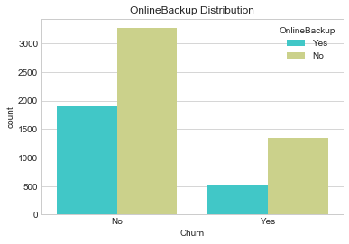

```python
sns.countplot(x='Churn',hue='OnlineBackup',data=data,palette='rainbow').set_title("OnlineBackup Distribution")
```

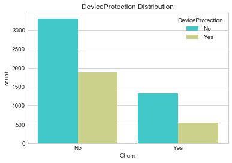

```python
sns.countplot(x='Churn',hue='DeviceProtection',data=data,palette='rainbow').set_title("DeviceProtection Distribution")
```

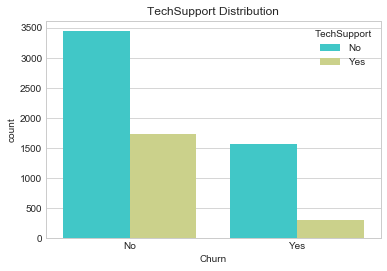

```python
sns.countplot(x='Churn',hue='TechSupport',data=data,palette='rainbow').set_title("TechSupport Distribution")
```

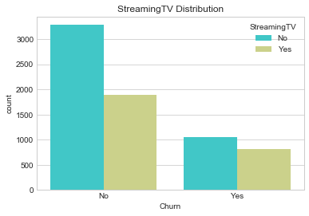

```python
sns.countplot(x='Churn',hue='StreamingTV',data=data,palette='rainbow').set_title("StreamingTV Distribution")
```

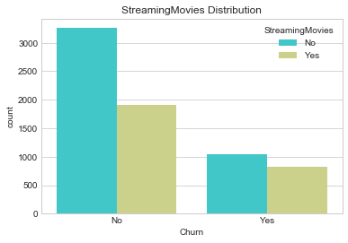

```python
sns.countplot(x='Churn',hue='StreamingMovies',data=data,palette='rainbow').set_title("StreamingMovies Distribution")
```

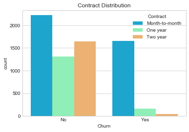

```python
sns.countplot(x='Churn',hue='Contract',data=data,palette='rainbow').set_title("Contract Distribution")
```

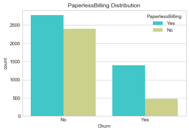

```python
sns.countplot(x='Churn',hue='PaperlessBilling',data=data,palette='rainbow').set_title("PaperlessBilling Distribution")
```

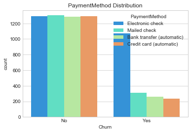

```python
sns.countplot(x='Churn',hue='PaymentMethod',data=data,palette='rainbow').set_title("PaymentMethod Distribution")
```

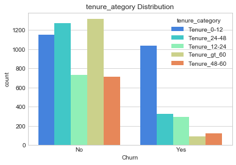

```python
sns.countplot(x='Churn',hue='tenure_category',data=data,palette='rainbow').set_title("tenure_ategory Distribution")
```

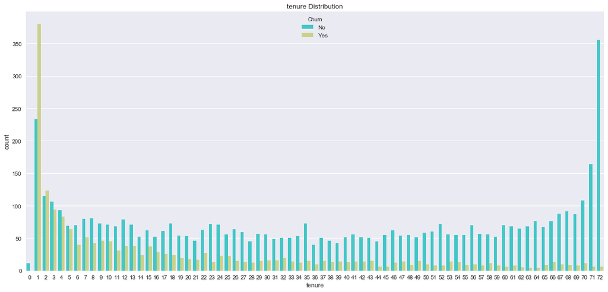

```python
sns.set(rc={'figure.figsize':(18,8.27)})
sns.countplot(x='tenure',hue='Churn',data=data,palette='rainbow').set_title("tenure Distribution")
```

[figure not shown]

```python
sns.set(rc={'figure.figsize':(20,8.27)})
sns.countplot(x='MonthlyCharges',hue='Churn',data=data,palette='rainbow').set_title("MonthlyCharges Distribution")
```

[figure not shown]

```python
sns.set(rc={'figure.figsize':(20,8.27)})
sns.countplot(x='TotalCharges',hue='Churn',data=data,palette='rainbow').set_title("TotalCharges Distribution")
```

#Numerical Columns are plotted in scater plot for the Churn values

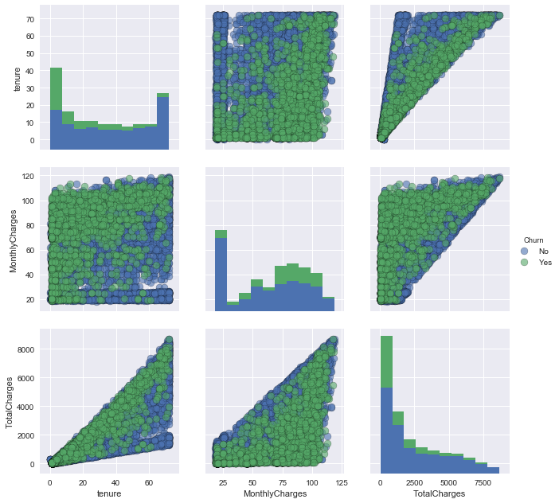

```python
sns.set(rc={'figure.figsize':(10,5)})
sns.pairplot(data,
             vars = ['tenure', 'MonthlyCharges', 'TotalCharges'],
             hue = 'Churn', diag_kind = 'hist',
             plot_kws = {'alpha': 0.6, 's': 80, 'edgecolor': 'k'},
             size = 3);
```

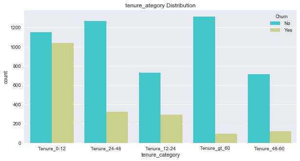

```python
sns.countplot(x='tenure_category',hue='Churn',data=data,palette='rainbow').set_title("tenure_ategory Distribution")
```

#The categorical columns are converted to dummies, which is the process to handle categorical values for a classifier model.

```python
data = pd.get_dummies(data, columns=['gender','Partner','Dependents','PhoneService','MultipleLines','InternetService','OnlineSecurity','OnlineBackup','DeviceProtection','TechSupport','StreamingMovies','Contract','PaperlessBilling','PaymentMethod','StreamingTV','SeniorCitizen'])
```

```python
data = pd.get_dummies(data, columns=['tenure_category'])
```

#Scaling of numerical values

```python
std = StandardScaler()
ncols=['tenure','MonthlyCharges','TotalCharges']
scaled = std.fit_transform(data[ncols])
scaled = pd.DataFrame(scaled,columns=ncols)
```

```python
data_copy=data.copy()
data = data.drop(columns = ncols,axis = 1)
```

```python
data = data.merge(scaled,left_index=True,right_index=True,how = "left")
```

#Finding the correlation between features

```python
correlation = data.corr()
correlation
```

|  | gender_Female | gender_Male | Partner_No | Partner_Yes | Dependents_No | Dependents_Yes | PhoneService_No | PhoneService_Yes | MultipleLines_No | MultipleLines_No phone service | ... | SeniorCitizen_No | SeniorCitizen_Yes | tenure_category_Tenure_0-12 | tenure_category_Tenure_12-24 | tenure_category_Tenure_24-48 | tenure_category_Tenure_48-60 | tenure_category_Tenure_gt_60 | tenure | MonthlyCharges | TotalCharges |
| --- | --- | --- | --- | --- | --- | --- | --- | --- | --- | --- | --- | --- | --- | --- | --- | --- | --- | --- | --- | --- | --- |
| gender_Female | 1.000000 | -1.000000 | -0.001808 | 0.001808 | 0.010517 | -0.010517 | -0.006488 | 0.006488 | -0.004476 | -0.006488 | ... | -0.001874 | 0.001874 | 0.000858 | 0.000701 | 0.010575 | 0.004362 | -0.016199 | -0.005106 | 0.014569 | 0.000065 |
| gender_Male | -1.000000 | 1.000000 | 0.001808 | -0.001808 | -0.010517 | 0.010517 | 0.006488 | -0.006488 | 0.004476 | 0.006488 | ... | 0.001874 | -0.001874 | -0.000858 | -0.000701 | -0.010575 | -0.004362 | 0.016199 | 0.005106 | -0.014569 | -0.000065 |
| Partner_No | -0.001808 | 0.001808 | 1.000000 | -1.000000 | 0.452676 | -0.452676 | 0.017706 | -0.017706 | 0.129929 | 0.017706 | ... | 0.016479 | -0.016479 | 0.302718 | 0.048868 | -0.027871 | -0.104860 | -0.279545 | -0.379697 | -0.096848 | -0.317689 |
| Partner_Yes | 0.001808 | -0.001808 | -1.000000 | 1.000000 | -0.452676 | 0.452676 | -0.017706 | 0.017706 | -0.129929 | -0.017706 | ... | -0.016479 | 0.016479 | -0.302718 | -0.048868 | 0.027871 | 0.104860 | 0.279545 | 0.379697 | 0.096848 | 0.317689 |
| Dependents_No | 0.010517 | -0.010517 | 0.452676 | -0.452676 | 1.000000 | -1.000000 | -0.001762 | 0.001762 | -0.023198 | -0.001762 | ... | -0.211185 | 0.211185 | 0.141295 | 0.002443 | -0.023301 | -0.030483 | -0.116656 | -0.159712 | 0.113890 | -0.062381 |
| Dependents_Yes | -0.010517 | 0.010517 | -0.452676 | 0.452676 | -1.000000 | 1.000000 | 0.001762 | -0.001762 | 0.023198 | 0.001762 | ... | 0.211185 | -0.211185 | -0.141295 | -0.002443 | 0.023301 | 0.030483 | 0.116656 | 0.159712 | -0.113890 | 0.062381 |
| PhoneService_No | -0.006488 | 0.006488 | 0.017706 | -0.017706 | -0.001762 | 0.001762 | 1.000000 | -1.000000 | -0.315431 | 1.000000 | ... | 0.008576 | -0.008576 | 0.007598 | -0.012473 | 0.014511 | 0.009571 | -0.020708 | -0.008448 | -0.247398 | -0.113179 |
| PhoneService_Yes | 0.006488 | -0.006488 | -0.017706 | 0.017706 | 0.001762 | -0.001762 | -1.000000 | 1.000000 | 0.315431 | -1.000000 | ... | -0.008576 | 0.008576 | -0.007598 | 0.012473 | -0.014511 | -0.009571 | 0.020708 | 0.008448 | 0.247398 | 0.113179 |
| MultipleLines_No | -0.004476 | 0.004476 | 0.129929 | -0.129929 | -0.023198 | 0.023198 | -0.315431 | 0.315431 | 1.000000 | -0.315431 | ... | 0.136213 | -0.136213 | 0.255402 | 0.051690 | -0.032079 | -0.080528 | -0.242520 | -0.323088 | -0.338314 | -0.396140 |
| MultipleLines_No phone service | -0.006488 | 0.006488 | 0.017706 | -0.017706 | -0.001762 | 0.001762 | 1.000000 | -1.000000 | -0.315431 | 1.000000 | ... | 0.008576 | -0.008576 | 0.007598 | -0.012473 | 0.014511 | 0.009571 | -0.020708 | -0.008448 | -0.247398 | -0.113179 |
| MultipleLines_Yes | 0.008414 | -0.008414 | -0.142057 | 0.142057 | 0.024526 | -0.024526 | -0.279690 | 0.279690 | -0.822853 | -0.279690 | ... | -0.142948 | 0.142948 | -0.262950 | -0.044828 | 0.023767 | 0.075742 | 0.257768 | 0.331941 | 0.490434 | 0.468566 |
| InternetService_DSL | -0.006568 | 0.006568 | 0.000851 | -0.000851 | -0.052010 | 0.052010 | 0.452425 | -0.452425 | -0.070179 | 0.452425 | ... | 0.108322 | -0.108322 | -0.000923 | -0.013565 | -0.000665 | -0.000923 | 0.014468 | 0.013274 | -0.160189 | -0.052434 |
| InternetService_Fiber optic | 0.011286 | -0.011286 | -0.000304 | 0.000304 | 0.165818 | -0.165818 | -0.289999 | 0.289999 | -0.190192 | -0.289999 | ... | -0.255338 | 0.255338 | -0.023455 | -0.000921 | 0.006358 | 0.017961 | 0.006799 | 0.019720 | 0.787066 | 0.361552 |
| InternetService_No | -0.006026 | 0.006026 | -0.000615 | 0.000615 | -0.139812 | 0.139812 | -0.172209 | 0.172209 | 0.310046 | -0.172209 | ... | 0.182742 | -0.182742 | 0.029322 | 0.016749 | -0.006894 | -0.020575 | -0.024871 | -0.039062 | -0.763557 | -0.375138 |
| OnlineSecurity_No | -0.017021 | 0.017021 | 0.143106 | -0.143106 | 0.080972 | -0.080972 | -0.092893 | 0.092893 | 0.151950 | -0.092893 | ... | -0.038653 | 0.038653 | 0.241371 | 0.055714 | -0.007542 | -0.071493 | -0.262805 | -0.327203 | -0.296594 | -0.411757 |
| OnlineSecurity_Yes | 0.017021 | -0.017021 | -0.143106 | 0.143106 | -0.080972 | 0.080972 | 0.092893 | -0.092893 | -0.151950 | 0.092893 | ... | 0.038653 | -0.038653 | -0.241371 | -0.055714 | 0.007542 | 0.071493 | 0.262805 | 0.327203 | 0.296594 | 0.411757 |
| OnlineBackup_No | -0.013773 | 0.013773 | 0.141498 | -0.141498 | 0.023671 | -0.023671 | -0.052312 | 0.052312 | 0.230852 | -0.052312 | ... | 0.066572 | -0.066572 | 0.266595 | 0.084028 | -0.023028 | -0.099080 | -0.278479 | -0.360277 | -0.441780 | -0.509325 |
| OnlineBackup_Yes | 0.013773 | -0.013773 | -0.141498 | 0.141498 | -0.023671 | 0.023671 | 0.052312 | -0.052312 | -0.230852 | 0.052312 | ... | -0.066572 | 0.066572 | -0.266595 | -0.084028 | 0.023028 | 0.099080 | 0.278479 | 0.360277 | 0.441780 | 0.509325 |
| DeviceProtection_No | -0.002105 | 0.002105 | 0.153786 | -0.153786 | 0.013963 | -0.013963 | -0.071227 | 0.071227 | 0.240960 | -0.071227 | ... | 0.059428 | -0.059428 | 0.273127 | 0.077286 | -0.044891 | -0.076761 | -0.275230 | -0.360653 | -0.482692 | -0.522085 |
| DeviceProtection_Yes | 0.002105 | -0.002105 | -0.153786 | 0.153786 | -0.013963 | 0.013963 | 0.071227 | -0.071227 | -0.240960 | 0.071227 | ... | -0.059428 | 0.059428 | -0.273127 | -0.077286 | 0.044891 | 0.076761 | 0.275230 | 0.360653 | 0.482692 | 0.522085 |
| TechSupport_No | -0.009212 | 0.009212 | 0.119999 | -0.119999 | 0.063268 | -0.063268 | -0.096340 | 0.096340 | 0.156425 | -0.096340 | ... | -0.060625 | 0.060625 | 0.237622 | 0.072049 | -0.021975 | -0.062554 | -0.264980 | -0.324221 | -0.338304 | -0.431991 |
| TechSupport_Yes | 0.009212 | -0.009212 | -0.119999 | 0.119999 | -0.063268 | 0.063268 | 0.096340 | -0.096340 | -0.156425 | 0.096340 | ... | 0.060625 | -0.060625 | -0.237622 | -0.072049 | 0.021975 | 0.062554 | 0.264980 | 0.324221 | 0.338304 | 0.431991 |
| StreamingMovies_No | -0.010487 | 0.010487 | 0.117412 | -0.117412 | -0.039741 | 0.039741 | -0.032959 | 0.032959 | 0.275256 | -0.032959 | ... | 0.120176 | -0.120176 | 0.222300 | 0.053907 | -0.025544 | -0.086907 | -0.207863 | -0.286111 | -0.627429 | -0.520099 |
| StreamingMovies_Yes | 0.010487 | -0.010487 | -0.117412 | 0.117412 | 0.039741 | -0.039741 | 0.032959 | -0.032959 | -0.275256 | 0.032959 | ... | -0.120176 | 0.120176 | -0.222300 | -0.053907 | 0.025544 | 0.086907 | 0.207863 | 0.286111 | 0.627429 | 0.520099 |
| Contract_Month-to-month | 0.003386 | -0.003386 | 0.280865 | -0.280865 | 0.231720 | -0.231720 | 0.000742 | -0.000742 | 0.086740 | 0.000742 | ... | -0.138360 | 0.138360 | 0.488147 | 0.140565 | -0.051159 | -0.197865 | -0.475498 | -0.645561 | 0.060165 | -0.444546 |
| Contract_One year | -0.008026 | 0.008026 | -0.082783 | 0.082783 | -0.068368 | 0.068368 | 0.002791 | -0.002791 | 0.002098 | 0.002791 | ... | 0.046262 | -0.046262 | -0.251426 | -0.016999 | 0.154034 | 0.158994 | 0.016358 | 0.202570 | 0.004904 | 0.170789 |
| Contract_Two year | 0.003695 | -0.003695 | -0.248091 | 0.248091 | -0.204613 | 0.204613 | -0.003519 | 0.003519 | -0.102937 | -0.003519 | ... | 0.117000 | -0.117000 | -0.328868 | -0.147406 | -0.087008 | 0.078997 | 0.537783 | 0.558533 | -0.074681 | 0.354843 |
| PaperlessBilling_No | -0.011754 | 0.011754 | -0.014877 | 0.014877 | -0.111377 | 0.111377 | 0.016505 | -0.016505 | 0.151864 | 0.016505 | ... | 0.156530 | -0.156530 | 0.005365 | -0.003744 | 0.004832 | -0.010987 | 0.000905 | -0.006152 | -0.352150 | -0.158479 |
| PaperlessBilling_Yes | 0.011754 | -0.011754 | 0.014877 | -0.014877 | 0.111377 | -0.111377 | -0.016505 | 0.016505 | -0.151864 | -0.016505 | ... | -0.156530 | 0.156530 | -0.005365 | 0.003744 | -0.004832 | 0.010987 | -0.000905 | 0.006152 | 0.352150 | 0.158479 |
| PaymentMethod_Bank transfer (automatic) | 0.016024 | -0.016024 | -0.110706 | 0.110706 | -0.052021 | 0.052021 | -0.007556 | 0.007556 | -0.070178 | -0.007556 | ... | 0.016159 | -0.016159 | -0.185616 | -0.046232 | 0.021779 | 0.060187 | 0.184158 | 0.243510 | 0.042812 | 0.186003 |
| PaymentMethod_Credit card (automatic) | -0.001215 | 0.001215 | -0.082029 | 0.082029 | -0.060267 | 0.060267 | 0.007721 | -0.007721 | -0.063921 | 0.007721 | ... | 0.024135 | -0.024135 | -0.184470 | -0.039428 | 0.028471 | 0.048314 | 0.179415 | 0.233006 | 0.030550 | 0.182890 |
| PaymentMethod_Electronic check | -0.000752 | 0.000752 | 0.083852 | -0.083852 | 0.150642 | -0.150642 | -0.003062 | 0.003062 | -0.080836 | -0.003062 | ... | -0.171718 | 0.171718 | 0.158529 | 0.030829 | -0.010961 | -0.030162 | -0.174797 | -0.208363 | 0.271625 | -0.059392 |
| PaymentMethod_Mailed check | -0.013744 | 0.013744 | 0.095125 | -0.095125 | -0.059071 | 0.059071 | 0.003319 | -0.003319 | 0.222605 | 0.003319 | ... | 0.153477 | -0.153477 | 0.185308 | 0.049500 | -0.037019 | -0.072699 | -0.160633 | -0.233852 | -0.377437 | -0.295586 |
| StreamingTV_No | -0.008393 | 0.008393 | 0.124666 | -0.124666 | -0.016558 | 0.016558 | -0.022574 | 0.022574 | 0.267528 | -0.022574 | ... | 0.105378 | -0.105378 | 0.220308 | 0.050161 | -0.028837 | -0.087917 | -0.197993 | -0.279756 | -0.629603 | -0.515058 |
| StreamingTV_Yes | 0.008393 | -0.008393 | -0.124666 | 0.124666 | 0.016558 | -0.016558 | 0.022574 | -0.022574 | -0.267528 | 0.022574 | ... | -0.105378 | 0.105378 | -0.220308 | -0.050161 | 0.028837 | 0.087917 | 0.197993 | 0.279756 | 0.629603 | 0.515058 |
| SeniorCitizen_No | -0.001874 | 0.001874 | 0.016479 | -0.016479 | -0.211185 | 0.211185 | 0.008576 | -0.008576 | 0.136213 | 0.008576 | ... | 1.000000 | -1.000000 | 0.028687 | -0.002144 | -0.020748 | -0.014434 | 0.002062 | -0.016567 | -0.220173 | -0.102941 |
| SeniorCitizen_Yes | 0.001874 | -0.001874 | -0.016479 | 0.016479 | 0.211185 | -0.211185 | -0.008576 | 0.008576 | -0.136213 | -0.008576 | ... | -1.000000 | 1.000000 | -0.028687 | 0.002144 | 0.020748 | 0.014434 | -0.002062 | 0.016567 | 0.220173 | 0.102941 |
| tenure_category_Tenure_0-12 | 0.000858 | -0.000858 | 0.302718 | -0.302718 | 0.141295 | -0.141295 | 0.007598 | -0.007598 | 0.255402 | 0.007598 | ... | 0.028687 | -0.028687 | 1.000000 | -0.276713 | -0.362850 | -0.245540 | -0.335199 | -0.755067 | -0.193180 | -0.593112 |
| tenure_category_Tenure_12-24 | 0.000701 | -0.000701 | 0.048868 | -0.048868 | 0.002443 | -0.002443 | -0.012473 | 0.012473 | 0.051690 | -0.012473 | ... | -0.002144 | 0.002144 | -0.276713 | 1.000000 | -0.223087 | -0.150962 | -0.206086 | -0.235469 | -0.046670 | -0.210018 |
| tenure_category_Tenure_24-48 | 0.010575 | -0.010575 | -0.027871 | 0.027871 | -0.023301 | 0.023301 | 0.014511 | -0.014511 | -0.032079 | 0.014511 | ... | -0.020748 | 0.020748 | -0.362850 | -0.223087 | 1.000000 | -0.197955 | -0.270239 | 0.084136 | 0.021011 | 0.026321 |
| tenure_category_Tenure_48-60 | 0.004362 | -0.004362 | -0.104860 | 0.104860 | -0.030483 | 0.030483 | 0.009571 | -0.009571 | -0.080528 | 0.009571 | ... | -0.014434 | 0.014434 | -0.245540 | -0.150962 | -0.197955 | 1.000000 | -0.182870 | 0.329639 | 0.070420 | 0.253230 |
| tenure_category_Tenure_gt_60 | -0.016199 | 0.016199 | -0.279545 | 0.279545 | -0.116656 | 0.116656 | -0.020708 | 0.020708 | -0.242520 | -0.020708 | ... | 0.002062 | -0.002062 | -0.335199 | -0.206086 | -0.270239 | -0.182870 | 1.000000 | 0.727136 | 0.185840 | 0.639487 |
| tenure | -0.005106 | 0.005106 | -0.379697 | 0.379697 | -0.159712 | 0.159712 | -0.008448 | 0.008448 | -0.323088 | -0.008448 | ... | -0.016567 | 0.016567 | -0.755067 | -0.235469 | 0.084136 | 0.329639 | 0.727136 | 1.000000 | 0.247900 | 0.826076 |
| MonthlyCharges | 0.014569 | -0.014569 | -0.096848 | 0.096848 | 0.113890 | -0.113890 | -0.247398 | 0.247398 | -0.338314 | -0.247398 | ... | -0.220173 | 0.220173 | -0.193180 | -0.046670 | 0.021011 | 0.070420 | 0.185840 | 0.247900 | 1.000000 | 0.651143 |
| TotalCharges | 0.000065 | -0.000065 | -0.317689 | 0.317689 | -0.062381 | 0.062381 | -0.113179 | 0.113179 | -0.396140 | -0.113179 | ... | -0.102941 | 0.102941 | -0.593112 | -0.210018 | 0.026321 | 0.253230 | 0.639487 | 0.826076 | 0.651143 | 1.000000 |

45 rows × 45 columns

```python
matrix_cols = correlation.columns.tolist()
matrix_cols
```

```
['gender_Female',
 'gender_Male',
 'Partner_No',
 'Partner_Yes',
 'Dependents_No',
 'Dependents_Yes',
 'PhoneService_No',
 'PhoneService_Yes',
 'MultipleLines_No',
 'MultipleLines_No phone service',
 'MultipleLines_Yes',
 'InternetService_DSL',
 'InternetService_Fiber optic',
 'InternetService_No',
 'OnlineSecurity_No',
 'OnlineSecurity_Yes',
 'OnlineBackup_No',
 'OnlineBackup_Yes',
 'DeviceProtection_No',
 'DeviceProtection_Yes',
 'TechSupport_No',
 'TechSupport_Yes',
 'StreamingMovies_No',
 'StreamingMovies_Yes',
 'Contract_Month-to-month',
 'Contract_One year',
 'Contract_Two year',
 'PaperlessBilling_No',
 'PaperlessBilling_Yes',
 'PaymentMethod_Bank transfer (automatic)',
 'PaymentMethod_Credit card (automatic)',
 'PaymentMethod_Electronic check',
 'PaymentMethod_Mailed check',
 'StreamingTV_No',
 'StreamingTV_Yes',
 'SeniorCitizen_No',
 'SeniorCitizen_Yes',
 'tenure_category_Tenure_0-12',
 'tenure_category_Tenure_12-24',
 'tenure_category_Tenure_24-48',
 'tenure_category_Tenure_48-60',
 'tenure_category_Tenure_gt_60',
 'tenure',
 'MonthlyCharges',
 'TotalCharges']
```

```python
corr_array  = np.array(correlation)
corr_array
```

```
array([[ 1.00000000e+00, -1.00000000e+00, -1.80807966e-03, ...,
        -5.10622262e-03,  1.45693237e-02,  6.47997280e-05],
       [-1.00000000e+00,  1.00000000e+00,  1.80807966e-03, ...,
         5.10622262e-03, -1.45693237e-02, -6.47997280e-05],
       [-1.80807966e-03,  1.80807966e-03,  1.00000000e+00, ...,
        -3.79697461e-01, -9.68479363e-02, -3.17689075e-01],
       ...,
       [-5.10622262e-03,  5.10622262e-03, -3.79697461e-01, ...,
         1.00000000e+00,  2.47899856e-01,  8.26075933e-01],
       [ 1.45693237e-02, -1.45693237e-02, -9.68479363e-02, ...,
         2.47899856e-01,  1.00000000e+00,  6.51143229e-01],
       [ 6.47997280e-05, -6.47997280e-05, -3.17689075e-01, ...,
         8.26075933e-01,  6.51143229e-01,  1.00000000e+00]])
```

# Logistic Regression Model

```python
from sklearn.model_selection import train_test_split
from sklearn.linear_model import LogisticRegression
from sklearn.metrics import confusion_matrix,accuracy_score,classification_report
from sklearn.metrics import roc_auc_score,roc_curve,scorer
from sklearn.metrics import f1_score
import statsmodels.api as sm
from sklearn.metrics import precision_score,recall_score
```

#30% data is randomly chosen as test data

```python
train,test = train_test_split(data,test_size=.30 ,random_state=50)
Id_col     = ['customerID']
target_col = ["Churn"]
```

```python
cols    = [i for i in data.columns if i not in Id_col + target_col]
train_X = train[cols]
train_Y = train[target_col]
test_X  = test[cols]
test_Y  = test[target_col]
```

```python
logmodel = LogisticRegression()
```

```python
logmodel.fit(train_X,train_Y)
```

```
LogisticRegression(C=1.0, class_weight=None, dual=False, fit_intercept=True,
          intercept_scaling=1, max_iter=100, multi_class='ovr', n_jobs=1,
          penalty='l2', random_state=None, solver='liblinear', tol=0.0001,
          verbose=0, warm_start=False)
```

```python
predictions=logmodel.predict(test_X)
print(classification_report(test_Y,predictions))
```

```
             precision    recall  f1-score   support

         No       0.85      0.89      0.87      1556
        Yes       0.65      0.57      0.61       557

avg / total       0.80      0.81      0.80      2113
```

The model prediction is 80.70% accurate

```python
print(accuracy_score(test_Y,predictions))
```

```
0.8069096071935636
```

```python
print(confusion_matrix(test_Y,predictions))
```

```
[[1390  166]
 [ 242  315]]
```